[figure not shown]

```python
from IPython.display import Image
Image('https://upload.wikimedia.org/wikipedia/commons/thumb/7/78/Ford_GoBike_logo.svg/800px-Ford_GoBike_logo.svg.png')
```

# Ford GoBike System Data Flights Analysis

## by *Furawa*

## Dataset Overview

The Ford GoBike System Data Flights includes information about individual rides made in a bike-sharing system covering the greater San Francisco Bay area. We will use the data of the year 2018, which is about 1863721 rides all over the year in different locations. The rides are made by different gender, people of all age, subcribers and customers.

## Investigation Overview

In this investigation the main focus is to know When and where most of the trips are taken in terms of time of a day, day of the week, or month of the year. We also want to know if this depend on if is a subscriber or a customer a Male or a Female a young or an old person.

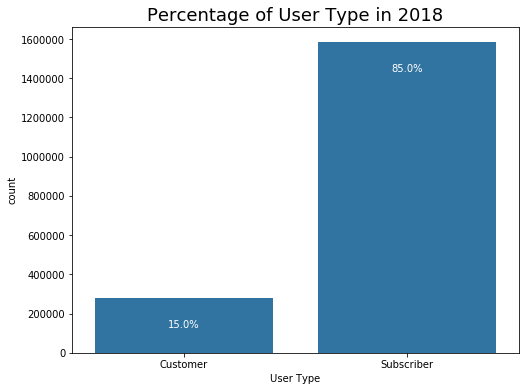

```python
# Create the plot of the user type
plt.figure(figsize = [8,6])
base_color = sb.color_palette()[0]
sb.countplot(data = baywheels_data, x = 'user_type', color = base_color)
plt.xlabel('User Type')
plt.title('Percentage of User Type in 2018', size = 18);

# add annotations
n_points = baywheels_data.shape[0]
cat_counts = baywheels_data.user_type.value_counts()
locs, labels = plt.xticks()

# loop through each pair of location and label
for loc, label in zip(locs, labels):
    count = cat_counts[label.get_text()]
    pct_string = '{:0.1f}%'.format(100*count/n_points)
    plt.text(loc, count-150000, pct_string, ha = 'center', color = 'w')
```

During the year 2018 of the **1,863,721** trips, **85%**(1,584,162) of the trips are made by Subscribers users and only **15%**(279558) are made by Customers.

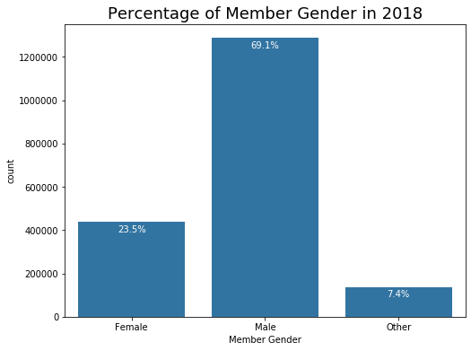

```python
# Plot Member gender
plt.figure(figsize = [8,6])
sb.countplot(data = baywheels_data, x = 'member_gender', color = base_color)
plt.xlabel('Member Gender')
plt.title('Percentage of Member Gender in 2018', size = 18)
# add annotations
gender_points = baywheels_data.shape[0]
gender_counts = baywheels_data.member_gender.value_counts()
gender_locs, gender_labels = plt.xticks()

# loop through each pair of location and label
for loc, label in zip(gender_locs, gender_labels):
    count = gender_counts[label.get_text()]
    pct_string = '{:0.1f}%'.format(100*count/gender_points)
    plt.text(loc, count-45000, pct_string, ha = 'center', color = 'w')
```

**69.1%** of the trips are made by Man and just around **23.5%** are made by Woman. There *7.4%* which made by gender of Other type, in this group there are also wrong values or bad entries.

## Bike Share for All Option

[figure not shown]

```python
Image('https://images.ctfassets.net/q8mvene1wzq4/6sb2hCQ6luI0DuA76rO14w/d56a4844d2dc805f401bf76d1b8e1e9c/bikes-getting-approved.png')
```

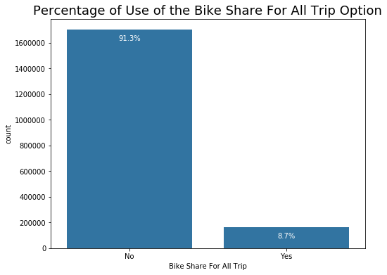

```python
plt.figure(figsize = [8,6])
sb.countplot(data = baywheels_data, x = 'bike_share_for_all_trip', color = base_color)
plt.xlabel('Bike Share For All Trip')
plt.title('Percentage of Use of the Bike Share For All Trip Option', size = 18)

option_points = baywheels_data.shape[0]
option_counts = baywheels_data.bike_share_for_all_trip.value_counts()
option_locs, gender_labels = plt.xticks()

# loop through each pair of location and label
for loc, label in zip(option_locs, gender_labels):
    count = option_counts[label.get_text()]
    pct_string = '{:0.1f}%'.format(100*count/option_points)
    plt.text(loc, count-85000, pct_string, ha = 'center', color = 'w');
```

Bay Wheels offers all residents of the Bay Area an affordable ,accessible and fun new transportation option, "*The Bike Share for All*", however this option seems to not attract many people, in fact just **8.7%** of all trips during the year 2018 are made using the option.

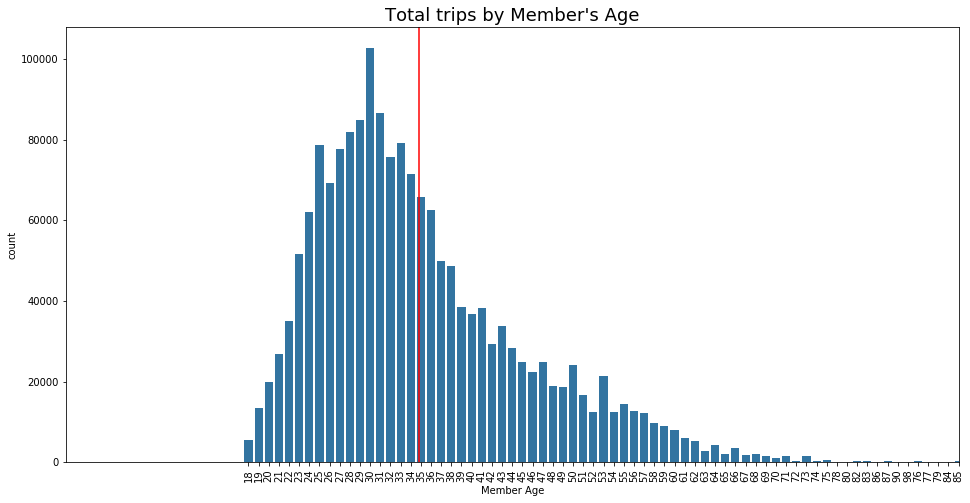

```python
# Use age instead of year
baywheels_data['member_age'] = pd.DatetimeIndex(baywheels_data.start_time).year.max() - baywheels_data.member_birth_year
# Change the size of the plot
plt.figure(figsize = (16,8))
# Plot the count of each member birth year
sb.countplot(data = baywheels_data, x = 'member_age', color = base_color)
# label the y axis
plt.xlabel('Member Age')
plt.xlim([-18,70])
plt.xticks(rotation = 90)
plt.title("Total trips by Member's Age", size = 18)
plt.axvline(x = baywheels_data.member_age.mean() - 18, c = 'r'); # -18 because we start at 18 on the axis
```

There where user with more that 100 years old, we did not take them in consideration because there are probably bad entries, we just considered the users with less than 85 years old in this plot and as we can see there are very few of them. On the other hand the rides are made by young people and we have the peak at 30 years old. We have an average years old of 35, and the youngest riders have 18 years old.

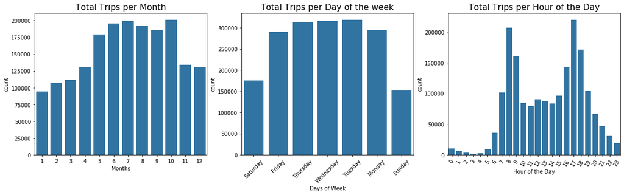

```python
# Change the size of the plots
plt.figure(figsize = [20,5])
# Add the Month plot on row 1 col 1
plt.subplot(1,3,1)
months = pd.DatetimeIndex(baywheels_data.start_time).month
sb.countplot(x = months, color = base_color)
plt.xlabel('Months')
plt.title('Total Trips per Month', size = 16)
# Add the Days plot on row 1 col 2
plt.subplot(1,3,2)
week_name = pd.DatetimeIndex(baywheels_data.start_time).weekday_name
sb.countplot(x = week_name, color = base_color)
plt.xlabel('Days of Week')
plt.xticks(rotation = 45)
plt.title('Total Trips per Day of the week', size = 16)
# Add the Hour plot on row 1 col 3
plt.subplot(1,3,3)
hours = pd.DatetimeIndex(baywheels_data.start_time).hour
sb.countplot(x = hours, color = base_color)
plt.xlabel('Hour of the Day')
plt.xticks(rotation = 60)
plt.title('Total Trips per Hour of the Day', size = 16);
```

From may(5) to october(10) we have the higher values with the highest at october which means that there are the period of the year 2018 with more trips. These values are a little bit expected in fact we have the highest values during the summer and autumn and the lowest during the winter and spring. In the other hands during the weedays we have the highest values and the lowest during the the weekends.  
There are more trips between 8am and 9am, and between 5pm and 6pm, which is also expected as these time of the day represents the start and the end of the work day. This let us think that the bicybles are more used when the weather is beautiful and during the work days, bicycles are probably more used to go and back from work.

```python
print('Duration max :', baywheels_data.duration_sec.max())      # Print the duration max over the year
print('Duration min :', baywheels_data.duration_sec.min())      # Print the duration min over the year
print('Average duration:', baywheels_data.duration_sec.mean())  # Print the average duration over the year
```

```
Duration max : 86366
Duration min : 61
Average duration: 857.3025710393348
```

The average duration over the year of a single trip is about **857s** which means around **14mn**, the minimum duration is about 1mn, and the max duration is about **24h** for one single trip.

Unexpectedly we have the longest trip(24h) at february by a customer.

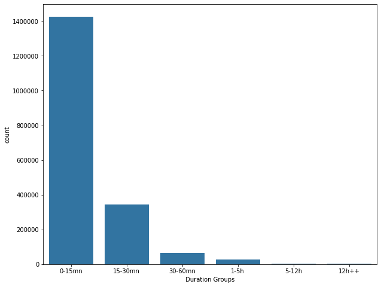

```python
# Plot the differents group
plt.figure(figsize = [10,8])
sb.countplot(data = baywheels_data, x = 'duration_groups', color = base_color)
plt.xlabel('Duration Groups');
```

There are more trip of less than 15mn, which means that in general and over the year all the trips are brief.

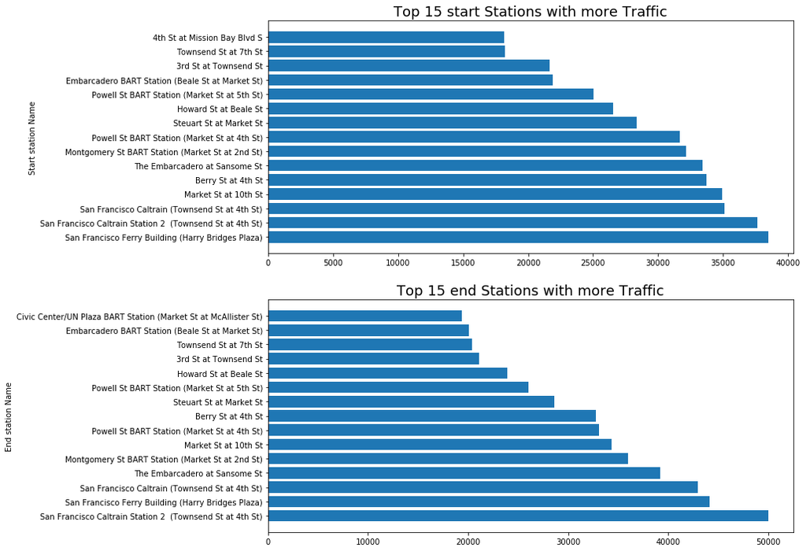

```python
# Plot top 15 stations with the highest number of trip over the year
plt.figure(figsize = [12,12])

# Retrieve the 15 start stations counts
start_counts = baywheels_data.start_station_name.value_counts()[:15]
# Retrieve the 15 start stations names
start_names = baywheels_data.start_station_name.value_counts()[:15].index
# Retrieve the 15 end stations counts
end_counts = baywheels_data.end_station_name.value_counts()[:15]
# Retrieve the 15 end stations names
end_names = baywheels_data.end_station_name.value_counts()[:15].index
# Plot the 15 start stations in the first subplot
plt.subplot(2,1,1)
plt.title('Top 15 start Stations with more Traffic', size = 18)
y_position = np.arange(len(start_names))
plt.barh(y_position, start_counts, align = 'center')
plt.yticks(y_position, start_names)
plt.ylabel('Start station Name')
# Plot the 15 start stations in the second subplot
plt.subplot(2,1,2)
plt.title('Top 15 end Stations with more Traffic', size = 18)
y_position = np.arange(len(end_names))
plt.barh(y_position, end_counts, align = 'center')
plt.yticks(y_position, end_names)
plt.ylabel('End station Name');
```

Just one station(4th St at Mission Bay Blvd S)are not in either list(start and end) of the 15 stations with the highest trips, so the other 14 even if in different order are the same in start and end. This stations are the ones with more traffic, the company may think about increase the number of bikes in those stations because they are surely too busy, If you want a quiet place avoid those stations!!

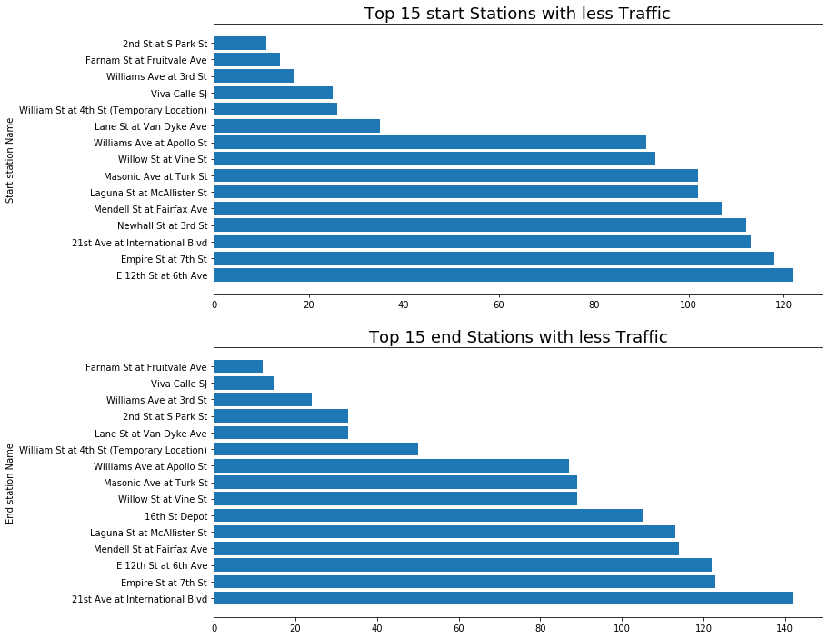

```python
# Plot top 15 stations with the lowest number of trips over the year

plt.figure(figsize = [12,12])
# Retrieve the 15 start stations counts
start_counts_2 = baywheels_data.start_station_name.value_counts().tail(15)
# Retrieve the 15 start stations names
start_names_2 = baywheels_data.start_station_name.value_counts().tail(15).index
# Retrieve the 15 end stations counts
end_counts_2 = baywheels_data.end_station_name.value_counts().tail(15)
# Retrieve the 15 end stations names
end_names_2 = baywheels_data.end_station_name.value_counts().tail(15).index
# Plot the 15 start stations in the first subplot
plt.subplot(2,1,1)
plt.title('Top 15 start Stations with less Traffic', size = 18)
y_position = np.arange(len(start_names_2))
plt.barh(y_position, start_counts_2, align = 'center')
plt.yticks(y_position, start_names_2)
plt.ylabel('Start station Name')
# Plot the 15 start stations in the second subplot
plt.subplot(2,1,2)
plt.title('Top 15 end Stations with less Traffic', size = 18)
y_position = np.arange(len(end_names_2))
plt.barh(y_position, end_counts_2, align = 'center')
plt.yticks(y_position, end_names_2)
plt.ylabel('End station Name');
```

Here we have the stations with less traffic during the year, there are stations like Farnam St at Fruitvale Ave with less than **20** trips all the year, In those stations you are sure to find a bike available. We cannot exactly know why those stations have so few trips, we do not have enough data, maybe the area has few people living there or there is no tourism or maybe there are not enough bike available with more data we could answer these questions.

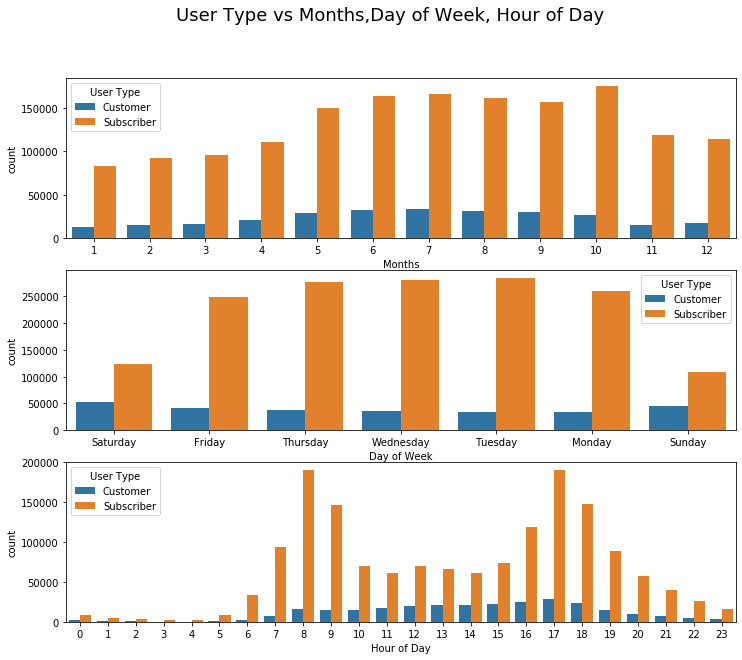

```python
# Plot months of the year vs user_type
plt.figure(figsize = [12,10])
plt.suptitle('User Type vs Months,Day of Week, Hour of Day', size = 18)
# Subplot months vs user type
plt.subplot(3,1,1)
sb.countplot(data = baywheels_data, x = months, hue = 'user_type')
plt.xlabel('Months')
plt.legend(title = 'User Type', loc = 'upper left')
# Subplot day of week vs user type
plt.subplot(3,1,2)
sb.countplot(data = baywheels_data, x = week_name, hue = 'user_type')
plt.xlabel('Day of Week')
plt.legend(title = 'User Type')
# Subplot hour of day  vs user type
plt.subplot(3,1,3)
sb.countplot(data = baywheels_data, x = hours, hue = 'user_type')
plt.xlabel('Hour of Day')
plt.legend(title = 'User Type', loc = 'upper left');
```

`Subcribers` and `Customers` do not follow the same pattern, for example there are more trips of `Customers` at july and during the weekends, when for `Subscribers` this occur at october and during the weekdays.  
During the day Customers have more trips between 11am and 6pm while for `Subscribers` this happen between 7am to 9am and 4pm to 9pm.

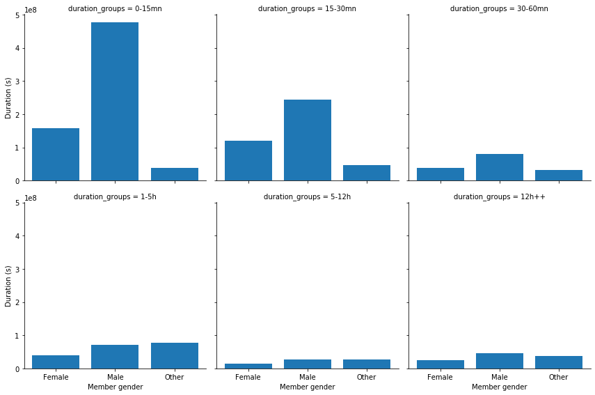

```python
# Group by duration group and member gender then sum the duration sec, reset index to have a dataframe
gender_duration_group = baywheels_data.groupby(['duration_groups','member_gender']).sum().duration_sec.reset_index()
# Facet per duration Groups
g = sb.FacetGrid(data = gender_duration_group, col = 'duration_groups', height = 4, col_wrap = 3)
g.map(plt.bar, 'member_gender', 'duration_sec')
g.set_xlabels('Member gender')
g.set_ylabels('Duration (s)');
```

In general Woman have less trip duration than Man no matter the group of duration.The Other category in the group of duration 1-5 hours has more duration time than the Male and Female categories.

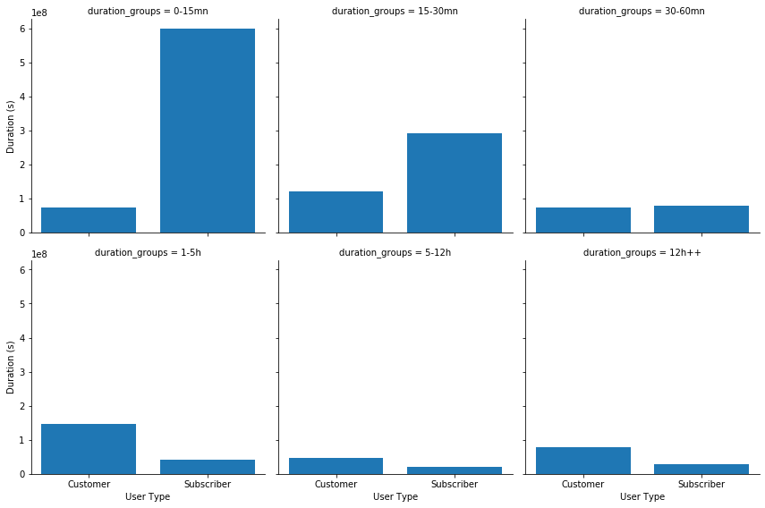

```python
# Group by duration and user type then calculate the total duration for the group and reset index to have df
user_duration_group = baywheels_data.groupby(['duration_groups','user_type']).sum().duration_sec.reset_index()
# Facet per duration Groups
g = sb.FacetGrid(data = user_duration_group, col = 'duration_groups', height = 4, col_wrap = 3)
g.map(plt.bar, 'user_type', 'duration_sec')
g.set_xlabels('User Type')
g.set_ylabels('Duration (s)');
```

Subscribers tend to have brief trips(less than 1 hour) than Customers, in fact from 1h to more than 12 hours Customers have a total duration trip higher than Subscribers.